Coding Essentials for Astronomers

# Data Visualization with Matplotlib

## Introduction

Every astronomical discovery needs visualization. From plotting your first light curve to creating figures for publication, visualization transforms numbers into understanding. Today we'll learn matplotlib, Python's fundamental plotting library that astronomers use daily.

We'll start with the simplest possible plot and gradually build up complexity. By the end, you'll be able to create any visualization you need for your astronomical research.

Let's begin by setting up our notebook environment:

```python
%matplotlib inline
```

This "magic command" (commands that start with `%`) tells Jupyter notebooks to display plots directly inline with your code, rather than opening them in separate windows. This makes it much easier to work interactively with your data.

While `%matplotlib inline` works in most Jupyter environments, it doesn't always work reliably everywhere. That's why we'll also use `plt.show()` after creating each plot. Think of `plt.show()` as "pushing" the plot to the screen - it explicitly tells matplotlib to render and display the figure. This is good practice because it makes your code more portable and ensures it works in any Python environment, not just Jupyter notebooks. We'll use `plt.show()` throughout this tutorial.

Now let's import the libraries we'll need:

```python
import matplotlib.pyplot as plt
import numpy as np
```

We import `matplotlib.pyplot` with the nickname `plt` because it's much shorter to type. This is a standard convention that you'll see in almost all astronomy code.

## Your First Plot

Let's start by making the most basic plot possible - just connecting some points with a line. We'll use NumPy arrays from the start, since they're the standard tool for numerical work in Python:

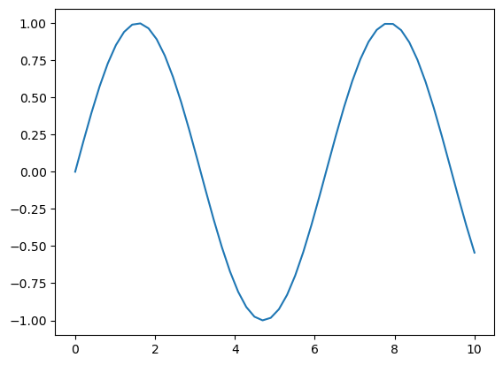

```python
# Create data points using NumPy arrays
x = np.linspace(0, 10, 50)  # 50 evenly spaced points from 0 to 10
y = np.sin(x)

# Plot them
plt.plot(x, y)
plt.show()
```

That's all it takes! The `plot()` function draws a line connecting your data points. The `linspace(start, stop, number)` function creates evenly spaced points - it's one of the most useful NumPy functions for plotting. With 50 points, the sine wave looks smooth and continuous.

But this plot has a serious problem - anyone looking at it has no idea what the axes represent. Are these measurements? Time series? Arbitrary units? We need labels.

**A plot without labels is essentially useless for science.** Let's fix this:

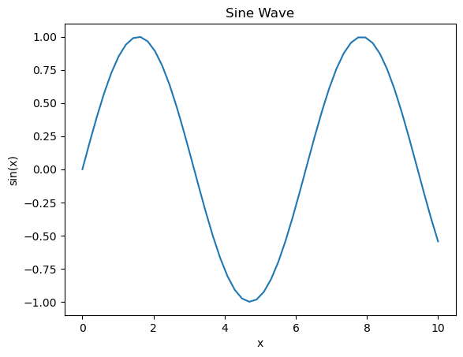

```python
x = np.linspace(0, 10, 50)
y = np.sin(x)

plt.plot(x, y)
plt.xlabel('x')  # Label for the horizontal axis
plt.ylabel('sin(x)')  # Label for the vertical axis
plt.title('Sine Wave')  # Title appears at the top
plt.show()
```

Now anyone can immediately understand what this plot represents. The `xlabel()` function adds text below the horizontal axis, while `ylabel()` adds text beside the vertical axis. **Always include units in parentheses when plotting physical quantities** - for example, 'Time (seconds)' or 'Distance (km)'.

With NumPy arrays, we can perform mathematical operations on entire arrays at once, which is perfect for plotting mathematical functions:

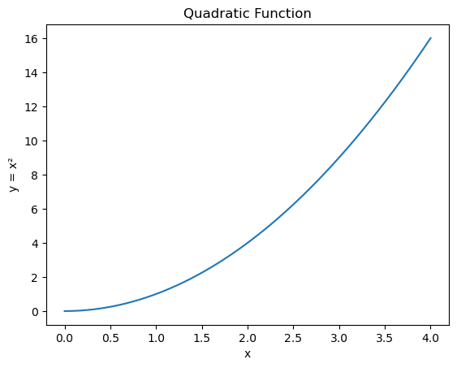

```python
# NumPy can apply operations to all elements at once
x = np.linspace(0, 4, 50)
y = x**2  # Square every element - no loops needed!

plt.plot(x, y)
plt.xlabel('x')
plt.ylabel('y = x²')
plt.title('Quadratic Function')
plt.show()
```

### Changing Line Colors

The default blue line isn't always what we want. Sometimes we need different colors to distinguish datasets or match publication requirements:

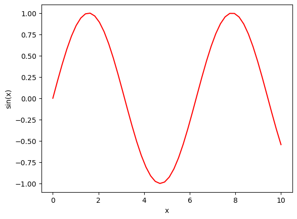

```python
x = np.linspace(0, 10, 50)
y = np.sin(x)

plt.plot(x, y, 'r')  # 'r' means red
plt.xlabel('x')
plt.ylabel('sin(x)')
plt.show()
```

Common color codes are: `'r'` (red), `'b'` (blue), `'g'` (green), `'k'` (black), `'m'` (magenta), `'y'` (yellow), `'c'` (cyan).

### Changing Line Styles

Sometimes we need dashed or dotted lines to distinguish different models or datasets:

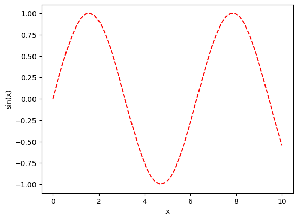

```python
plt.plot(x, y, 'r--')  # Red and dashed
plt.xlabel('x')
plt.ylabel('sin(x)')
plt.show()
```

The format string `'r--'` combines color and style. The first character sets the color, and the following characters set the line style:

- `'-'` creates a solid line
- `'--'` creates a dashed line
- `':'` creates a dotted line
- `'-.'` creates a dash-dot line

### Being More Explicit with Keywords

Instead of cryptic format strings, we can spell things out clearly using keyword arguments:

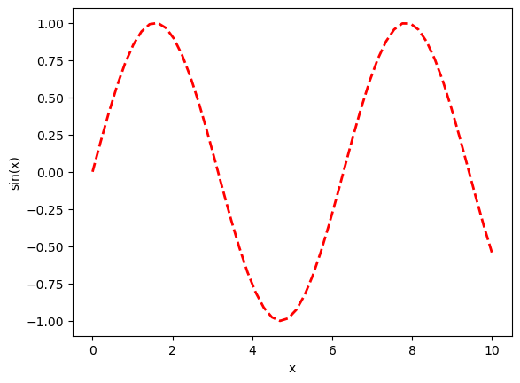

```python
plt.plot(x, y, color='red', linestyle='--', linewidth=2)
plt.xlabel('x')
plt.ylabel('sin(x)')
plt.show()
```

This is much clearer to read, especially for someone new to your code. The `linewidth` parameter controls the thickness of the line in points (1/72 of an inch).

### Plotting Multiple Lines

Often in astronomy we need to compare multiple datasets or models on the same plot:

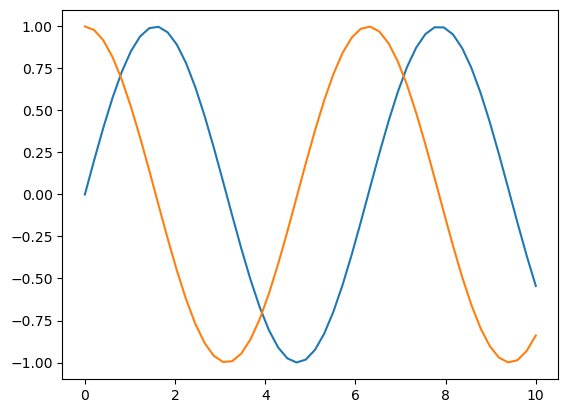

```python
x = np.linspace(0, 10, 50)

plt.plot(x, np.sin(x))  # First line
plt.plot(x, np.cos(x))  # Second line
plt.show()
```

But which line is which? We need to add labels and a legend:

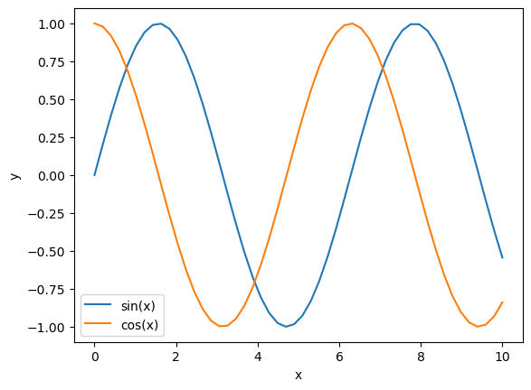

```python
plt.plot(x, np.sin(x), label='sin(x)')  # Add a label
plt.plot(x, np.cos(x), label='cos(x)')  # Add another label
plt.xlabel('x')
plt.ylabel('y')
plt.legend()  # Display the labels in a box
plt.show()
```

The `legend()` function creates a box showing what each line represents. Without calling `legend()`, the labels won't appear even though we specified them.

### Adding a Grid for Easier Reading

Grid lines help readers estimate values from your plot more accurately:

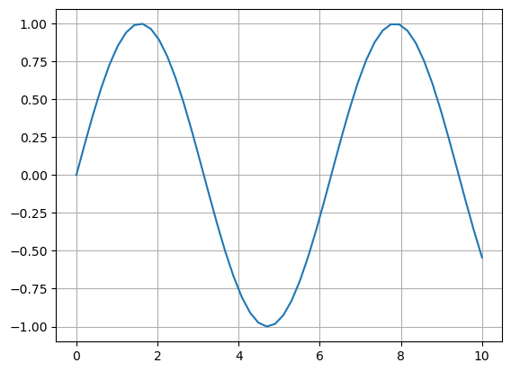

```python
x = np.linspace(0, 10, 50)
plt.plot(x, np.sin(x))
plt.grid(True)  # Add grid lines at the tick marks
plt.show()
```

If the grid is too prominent and distracts from the data, make it more subtle:

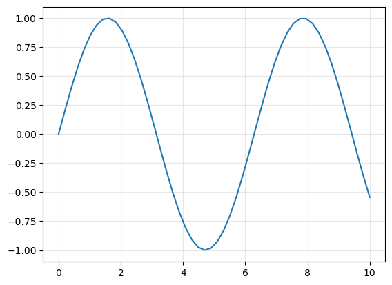

```python
plt.plot(x, np.sin(x))
plt.grid(True, alpha=0.3)  # alpha controls transparency (0=invisible, 1=solid)
plt.show()
```

The `alpha` parameter works throughout matplotlib to control transparency.

## Essential Plot Types for Astronomy

### Scatter Plots

When we have individual measurements rather than a continuous function, we use scatter plots. This is common in astronomy where we observe discrete objects:

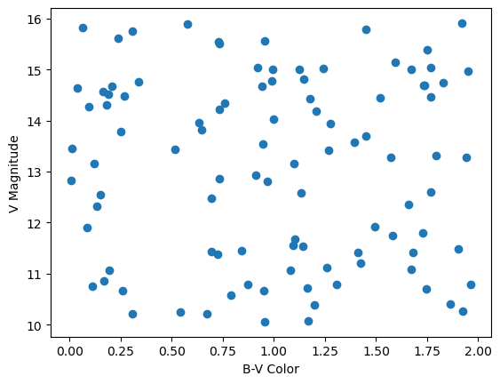

```python
# Simulate 100 stars with random properties
n_stars = 100
color = np.random.uniform(0, 2, n_stars)      # Random colors between 0 and 2
magnitude = np.random.uniform(10, 16, n_stars)  # Random magnitudes between 10 and 16

plt.scatter(color, magnitude)
plt.xlabel('B-V Color')
plt.ylabel('V Magnitude')
plt.show()
```

The `scatter()` function plots points without connecting them with lines. This is fundamentally different from `plot()` which draws lines between points.

### Flipping the Y-Axis

In astronomy, brighter objects have smaller magnitude values (magnitude 1 is brighter than magnitude 5). This is counterintuitive, so we need to flip the y-axis to match the convention:

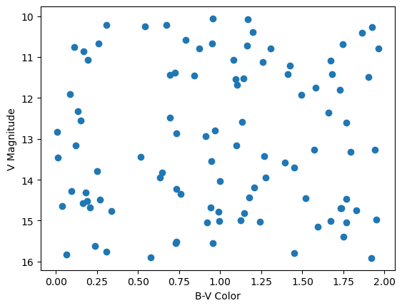

```python
plt.scatter(color, magnitude)
plt.xlabel('B-V Color')
plt.ylabel('V Magnitude')
plt.gca().invert_yaxis()  # Flip the y-axis!
plt.show()
```

The `gca()` function means "get current axes" - it returns the current plotting area as an object. Then `invert_yaxis()` flips the y-axis direction. This is essential for any magnitude plot in astronomy!

### Customizing Point Appearance

You can control every aspect of how your data points look:

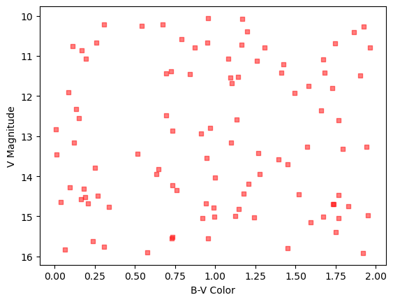

```python
plt.scatter(color, magnitude,
            s=20,       # Size of points in points squared
            c='red',    # Color (can also be an array for color-mapping)
            marker='s', # Shape: 'o'=circle, 's'=square, '^'=triangle
            alpha=0.5)  # Transparency
plt.xlabel('B-V Color')
plt.ylabel('V Magnitude')
plt.gca().invert_yaxis()
plt.show()
```

Different markers help distinguish different types of objects (stars vs galaxies, for example).

### Using Transparency to Reveal Density

When plotting thousands of points, they overlap and create solid blobs. Transparency helps reveal the underlying density structure:

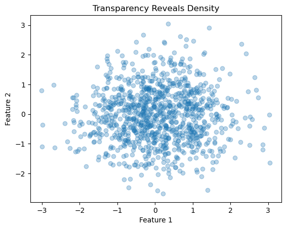

```python
# Generate many overlapping points
n_stars = 1000
x = np.random.normal(0, 1, n_stars)  # Normal distribution, mean=0, std=1
y = np.random.normal(0, 1, n_stars)

plt.scatter(x, y, alpha=0.3)  # alpha=0.3 means 30% opacity
plt.xlabel('Feature 1')
plt.ylabel('Feature 2')
plt.title('Transparency Reveals Density')
plt.show()
```

Without the `alpha` parameter, overlapping points would create an opaque blob. With transparency, darker regions show where more points overlap, revealing the density structure.

### Histograms

Histograms show how data is distributed, answering questions like "How many stars have magnitude 15?" Let's look at the magnitude distribution in a star cluster:

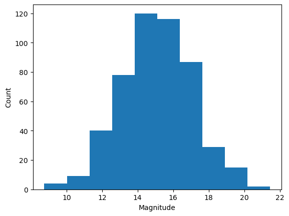

```python
# Simulate cluster magnitudes - normal distribution around magnitude 15
magnitudes = np.random.normal(15, 2, 500)  # 500 stars, mean=15, std=2

plt.hist(magnitudes)
plt.xlabel('Magnitude')
plt.ylabel('Count')
plt.show()
```

The `hist()` function automatically divides your data into bins and counts how many values fall in each bin, displaying the result as bars.

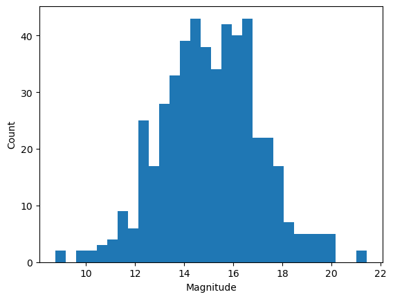

```python
plt.hist(magnitudes, bins=30)  # Use 30 bins instead of the default 10
plt.xlabel('Magnitude')
plt.ylabel('Count')
plt.show()
```

More bins show finer structure, but too many bins can make the histogram noisy. Choose a number that reveals the important features without over-fragmenting the data.

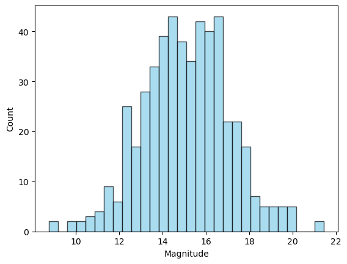

```python
plt.hist(magnitudes,
         bins=30,
         color='skyblue',     # Fill color
         edgecolor='black',   # Black edges make bars distinct
         alpha=0.7)           # Slight transparency
plt.xlabel('Magnitude')
plt.ylabel('Count')
plt.show()
```

The black edges help distinguish individual bars, especially important when presenting in black and white.

### Error Bars

Real astronomical measurements always have uncertainties. It's crucial to show these in your plots:

```python
# Photometry measurements over several nights
time = np.array([1, 2, 3, 4, 5])
flux = np.array([10.2, 10.5, 9.8, 10.1, 10.3])
flux_error = np.array([0.2, 0.15, 0.3, 0.2, 0.25])
```

Plot the data with error bars:

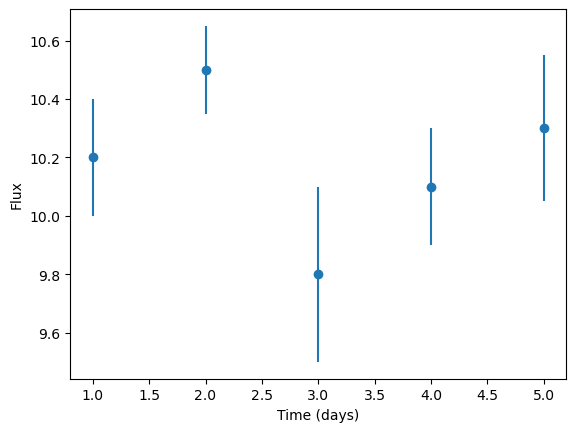

```python
plt.errorbar(time, flux, yerr=flux_error, fmt='o')
plt.xlabel('Time (days)')
plt.ylabel('Flux')
plt.show()
```

The `yerr` parameter adds vertical error bars (use `xerr` for horizontal). The `fmt='o'` makes the data points circles - without this, points would be connected by lines (as we have seen in plt.plot above). The parameter is called `fmt` because it stands for "format string" - it controls how the data points and lines are formatted/displayed.

Making error bars more visible:

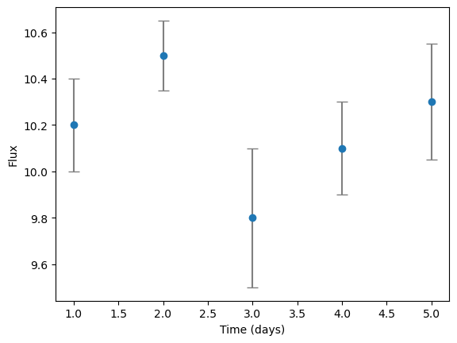

```python
plt.errorbar(time, flux, yerr=flux_error,
             fmt='o',        # Circle markers for data points
             capsize=5,      # Width of error bar caps (the horizontal lines)
             markersize=6,   # Size of the data points
             ecolor='gray')  # Color of error bars
plt.xlabel('Time (days)')
plt.ylabel('Flux')
plt.show()
```

The caps (horizontal lines at the ends of error bars) make the extent of uncertainties clearer.

### Error Bars in Both Dimensions

Often we have uncertainties in both measurements. For example, in a color-magnitude diagram, both color and magnitude have errors:

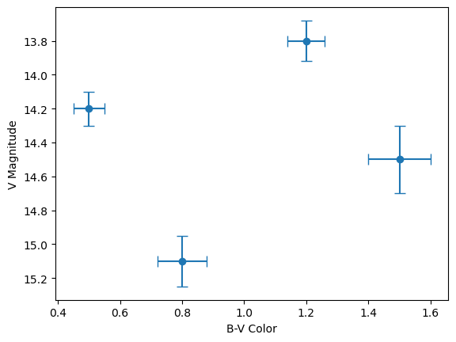

```python
# Color and magnitude with uncertainties
color = np.array([0.5, 0.8, 1.2, 1.5])
magnitude = np.array([14.2, 15.1, 13.8, 14.5])
color_err = np.array([0.05, 0.08, 0.06, 0.1])
mag_err = np.array([0.1, 0.15, 0.12, 0.2])

plt.errorbar(color, magnitude,
             xerr=color_err,  # Horizontal error bars
             yerr=mag_err,     # Vertical error bars
             fmt='o',
             capsize=5)
plt.xlabel('B-V Color')
plt.ylabel('V Magnitude')
plt.gca().invert_yaxis()
plt.show()
```

Using both `xerr` and `yerr` shows the full uncertainty ellipse for each measurement.

### Shaded Uncertainty Regions

When showing model predictions with uncertainty bands, shaded regions are clearer than many individual error bars:

```python
x = np.linspace(0, 10, 100)
y = np.sin(x)
```

Now add an uncertainty band:

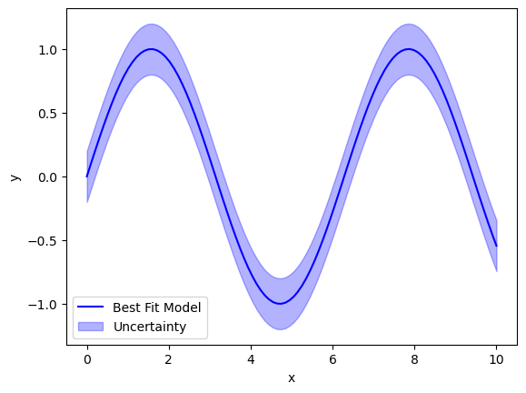

```python
plt.plot(x, y, 'b-', label='Best Fit Model')

# Create shaded region from y-0.2 to y+0.2
plt.fill_between(x, y - 0.2, y + 0.2,
                 alpha=0.3,     # Semi-transparent
                 color='blue',
                 label='Uncertainty')

plt.xlabel('x')
plt.ylabel('y')
plt.legend()
plt.show()
```

The `fill_between()` function creates a shaded area between two curves. The first argument is x-coordinates, second is the lower boundary, third is the upper boundary.

### Logarithmic Scales

Astronomical data often spans many orders of magnitude - from planets to stars to galaxies. Linear scales can't show such ranges effectively:

```python
# Stellar masses from 0.1 to 100 solar masses
masses = np.logspace(-1, 2, 50)  # Creates log-spaced points
```

The `logspace()` function creates points evenly spaced in logarithmic space. Now let's plot the mass-luminosity relation:

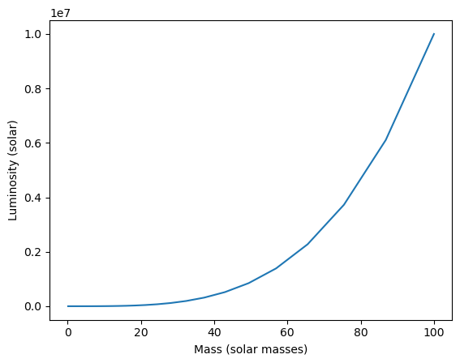

```python
luminosities = masses**3.5  # Approximate L ∝ M^3.5 relation

plt.plot(masses, luminosities)
plt.xlabel('Mass (solar masses)')
plt.ylabel('Luminosity (solar)')
plt.show()
```

Low-mass stars are invisible on this linear scale! Switch to log scales:

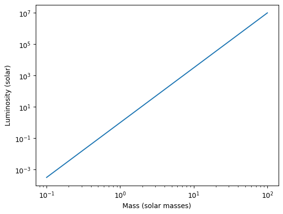

```python
plt.plot(masses, luminosities)
plt.xlabel('Mass (solar masses)')
plt.ylabel('Luminosity (solar)')
plt.xscale('log')  # Make x-axis logarithmic
plt.yscale('log')  # Make y-axis logarithmic
plt.show()
```

Now we can see stars across the entire mass range clearly! Log scales are essential when your data spans multiple orders of magnitude.

## Working with Figures and Axes

So far we've used simple commands like `plt.plot()`. This works well for single plots, but for complex figures we need more control. Let's understand matplotlib's structure better.

Remember from our object-oriented programming lectures: Python has two ways to use functionality - you can call functions directly (like `plt.plot()`), or you can create objects and call their methods (like `ax.plot()`). The second approach gives us more control and is essential for complex figures.

### Understanding Figures and Axes

Every matplotlib plot consists of two main components:

- **Figure**: The entire window or page (think of it as your canvas or piece of paper)
- **Axes**: The actual plotting area where your data appears (the box with tick marks and labels)

Let's create these explicitly:

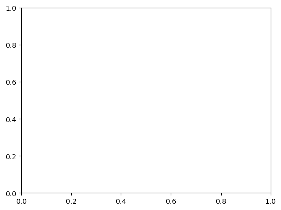

```python
fig, ax = plt.subplots()
plt.show()
```

This creates a figure (the whole window) and one axes (the plotting area). Now we use the axes object `ax` to plot, rather than `plt`:

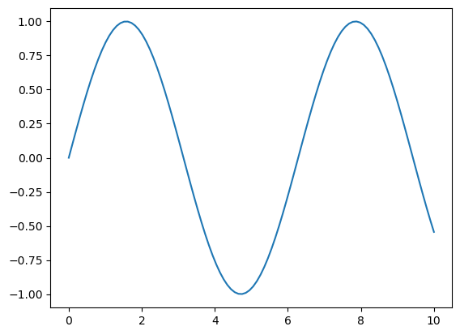

```python
fig, ax = plt.subplots()

x = np.linspace(0, 10, 100)
ax.plot(x, np.sin(x))  # Note: ax.plot, not plt.plot
plt.show()
```

When we use the axes object, we call slightly different methods:

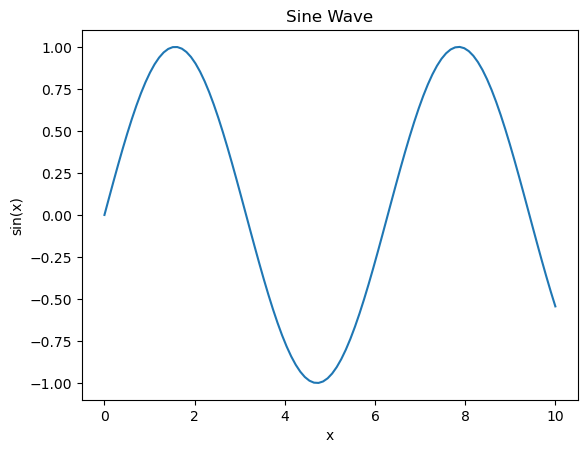

```python
fig, ax = plt.subplots()

ax.plot(x, np.sin(x))
ax.set_xlabel('x')      # Note: set_xlabel, not xlabel
ax.set_ylabel('sin(x)')
ax.set_title('Sine Wave')
plt.show()
```

Notice the method names are slightly different: `set_xlabel` instead of `xlabel`. This is because we're calling methods on the axes object. The axes object bundles the plotting area with all its methods for modifying it - it's an example of object-oriented programming where data and functions are packaged together.

### Creating Multiple Plots Side by Side

The real advantage of this approach becomes clear when we need multiple plots:

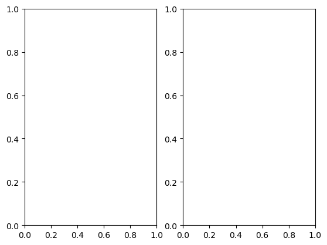

```python
fig, (ax1, ax2) = plt.subplots(1, 2)  # 1 row, 2 columns
plt.show()
```

This creates one figure containing two axes (plotting areas). Now we can plot different things in each:

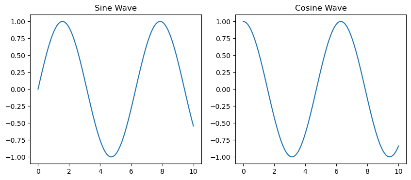

```python
fig, (ax1, ax2) = plt.subplots(1, 2, figsize=(10, 4))

# Left plot
x = np.linspace(0, 10, 100)
ax1.plot(x, np.sin(x))
ax1.set_title('Sine Wave')

# Right plot
ax2.plot(x, np.cos(x))
ax2.set_title('Cosine Wave')

plt.show()
```

The `figsize=(width, height)` parameter sets the overall figure size in inches.

### Creating a Grid of Plots

For a 2×2 grid of plots, `subplots` returns a 2D array of axes:

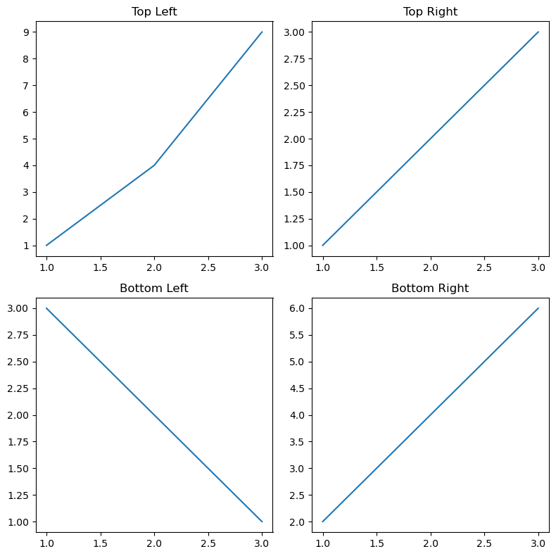

```python
fig, axes = plt.subplots(2, 2, figsize=(8, 8))

# Top-left plot: row 0, column 0
axes[0, 0].plot([1, 2, 3], [1, 4, 9])
axes[0, 0].set_title('Top Left')

# Top-right plot: row 0, column 1
axes[0, 1].plot([1, 2, 3], [1, 2, 3])
axes[0, 1].set_title('Top Right')

# Bottom-left plot: row 1, column 0
axes[1, 0].plot([1, 2, 3], [3, 2, 1])
axes[1, 0].set_title('Bottom Left')

# Bottom-right plot: row 1, column 1
axes[1, 1].plot([1, 2, 3], [2, 4, 6])
axes[1, 1].set_title('Bottom Right')

plt.tight_layout()
plt.show()
```

The `tight_layout()` function automatically adjusts the spacing between subplots to prevent any overlapping text.

### Sharing Axes for Easy Comparison

When comparing time series data (like light curves from different stars), it's helpful to link the axes so they zoom together:

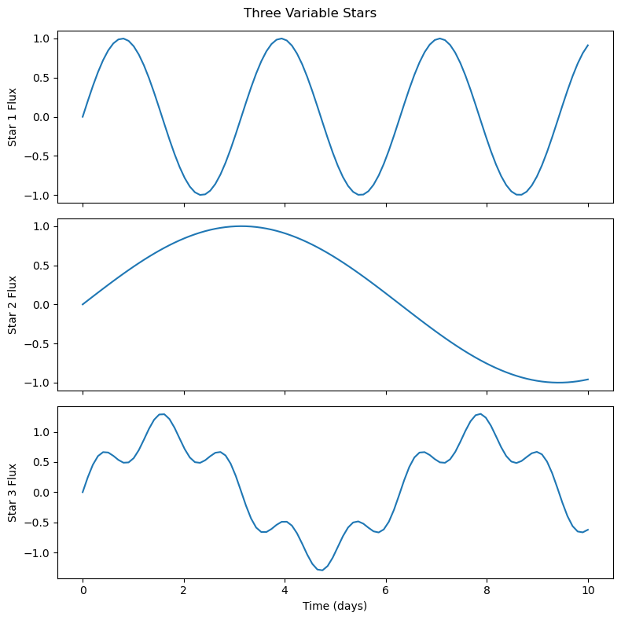

```python
fig, axes = plt.subplots(3, 1, sharex=True, figsize=(8, 8))

time = np.linspace(0, 10, 100)

# Top plot - fast variable
axes[0].plot(time, np.sin(2*time))
axes[0].set_ylabel('Star 1 Flux')

# Middle plot - slow variable
axes[1].plot(time, np.sin(0.5*time))
axes[1].set_ylabel('Star 2 Flux')

# Bottom plot - irregular variable
axes[2].plot(time, np.sin(time) + 0.3*np.sin(5*time))
axes[2].set_ylabel('Star 3 Flux')
axes[2].set_xlabel('Time (days)')  # Only label the bottom axis

plt.suptitle('Three Variable Stars')  # Overall title for all subplots
plt.tight_layout()
plt.show()
```

With `sharex=True`, all x-axes are linked together. When you zoom or pan one plot, all three move together.

### Two Different Y-Axes

Sometimes you need to plot quantities with different units on the same plot. For example, temperature and pressure over time:

```python
fig, ax1 = plt.subplots()

# First y-axis (left side) - temperature
time = np.linspace(0, 10, 100)
temperature = 20 + 5*np.sin(time)

ax1.plot(time, temperature, 'r-')
ax1.set_xlabel('Time (hours)')
ax1.set_ylabel('Temperature (°C)', color='r')
ax1.tick_params(axis='y', labelcolor='r')  # Make tick labels red to match line
```

```
None
```

Now add a second y-axis on the right:

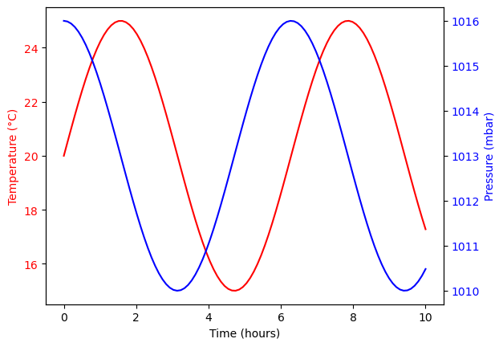

```python
ax2 = ax1.twinx()  # Create a twin axis sharing the same x-axis

# Second y-axis (right side) - pressure
pressure = 1013 + 3*np.cos(time)
ax2.plot(time, pressure, 'b-')
ax2.set_ylabel('Pressure (mbar)', color='b')
ax2.tick_params(axis='y', labelcolor='b')

plt.show()
```

The `twinx()` method creates a second y-axis that shares the same x-axis. This is useful when plotting related quantities with different units or scales.

## Inset Plots

Sometimes you need to show both the full view and a zoomed detail. Let's create a variable star light curve with an inset showing a single pulsation:

```python
# Create main plot
fig, ax = plt.subplots(figsize=(10, 6))

# Generate pulsating star data
time = np.linspace(0, 30, 1000)
period = 2.5
flux = 1.0 + 0.2*np.sin(2*np.pi*time/period)
flux += np.random.normal(0, 0.01, len(time))  # Add noise

# Main plot
ax.scatter(time, flux, s=1, alpha=0.5)
ax.set_xlabel('Time (days)')
ax.set_ylabel('Normalized Flux')
ax.set_title('Pulsating Variable Star')
```

Now add an inset to zoom in on one pulsation:

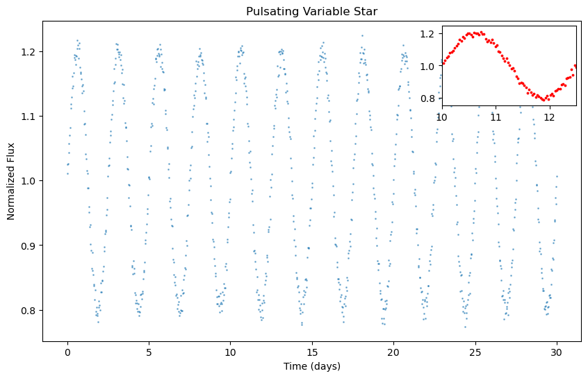

```python
# Create inset axes - position and size as fractions of main axes
from mpl_toolkits.axes_grid1.inset_locator import inset_axes
axins = inset_axes(ax, width="25%", height="25%", loc='upper right')

# Plot zoomed region - one complete pulsation
zoom_mask = (time > 10) & (time < 12.5)
axins.scatter(time[zoom_mask], flux[zoom_mask], s=3, color='red')
axins.set_xlim(10, 12.5)
axins.set_ylim(0.75, 1.25)

plt.show()
```

The inset clearly shows the shape of a single pulsation cycle while the main plot shows the long-term behavior.